# AllLifeBank_Sourojit_Dhua_AIML_ML_Project_full_code_notebook

## Problem Statement

### Context

AllLife Bank is a US bank that has a growing customer base. The majority of these customers are liability customers (depositors) with varying sizes of deposits. The number of customers who are also borrowers (asset customers) is quite small, and the bank is interested in expanding this base rapidly to bring in more loan business and in the process, earn more through the interest on loans. In particular, the management wants to explore ways of converting its liability customers to personal loan customers (while retaining them as depositors).

A campaign that the bank ran last year for liability customers showed a healthy conversion rate of over 9% success. This has encouraged the retail marketing department to devise campaigns with better target marketing to increase the success ratio.

You as a Data scientist at AllLife bank have to build a model that will help the marketing department to identify the potential customers who have a higher probability of purchasing the loan.

### Objective

To predict whether a liability customer will buy personal loans, to understand which customer attributes are most significant in driving purchases, and identify which segment of customers to target more.

### Data Dictionary

- `ID`: Customer ID
- `Age`: Customer’s age in completed years
- `Experience`: #years of professional experience
- `Income`: Annual income of the customer (in thousand dollars)
- `ZIP Code`: Home Address ZIP code.
- `Family`: the Family size of the customer
- `CCAvg`: Average spending on credit cards per month (in thousand dollars)
- `Education`: Education Level. 1: Undergrad; 2: Graduate;3: Advanced/Professional
- `Mortgage`: Value of house mortgage if any. (in thousand dollars)
- `Personal_Loan`: Did this customer accept the personal loan offered in the last campaign? (0: No, 1: Yes)
- `Securities_Account`: Does the customer have securities account with the bank? (0: No, 1: Yes)
- `CD_Account`: Does the customer have a certificate of deposit (CD) account with the bank? (0: No, 1: Yes)
- `Online`: Do customers use internet banking facilities? (0: No, 1: Yes)
- `CreditCard`: Does the customer use a credit card issued by any other Bank (excluding All life Bank)? (0: No, 1: Yes)

## Importing necessary libraries

```python
# Installing the libraries with the specified version.
#OLD
# Removed pandas==1.5.3 due to dependencies
#!pip install numpy==1.25.2 pandas==1.5.3 matplotlib==3.7.1 seaborn==0.13.1 scikit-learn==1.2.2 sklearn-pandas==2.2.0 -q --user

#NEW
!pip install numpy==1.25.2 matplotlib==3.7.1 seaborn==0.13.1 scikit-learn==1.2.2 sklearn-pandas==2.2.0 -q --user
```

**Note**:

1. After running the above cell, kindly restart the notebook kernel (for Jupyter Notebook) or runtime (for Google Colab), write the relevant code for the project from the next cell, and run all cells sequentially from the next cell.
2. On executing the above line of code, you might see a warning regarding package dependencies. This error message can be ignored as the above code ensures that all necessary libraries and their dependencies are maintained to successfully execute the code in this notebook.

```python
# Importing the required libraries for data manipulation
import pandas as pd
import numpy as np

# import libraries for data visualization
import matplotlib.pyplot as plt
import seaborn as sns

# Library to split data between learning and test sets
from sklearn.model_selection import train_test_split

# To build model for prediction
from sklearn.tree import DecisionTreeClassifier
from sklearn import tree

# To get the diferent decision tree metric scores
from sklearn.metrics import (
    f1_score,
    accuracy_score,
    recall_score,
    precision_score,
    confusion_matrix,
)

# to suppress unnecessary warnings
import warnings
warnings.filterwarnings("ignore")
```

## Loading the dataset

```python
# uncomment the following lines if Google Colab is being used
# Loading dataset from my Google Drive same way I did on the 1st Project for Food Hub
from google.colab import drive
drive.mount('/content/drive')
```

## Reading the dataset

```python
# Inputting the file path from my Google Drive to where the foodhub_order.csv data set is located

df = pd.read_csv('/content/drive/MyDrive/Colab Notebooks/Loan_Modelling.csv')
```

```python
# copying data set to another variable to avoid any changes to original data set
data = df.copy()
```

## Understanding the structure of the data

### View the first and last 5 rows of the dataset.

```python
# Viewing the head(5) or first 5 rows of the dataset.
# Note there is no need to put in the numerical (5), I just did explicitly.
data.head(5)
```

|  | ID | Age | Experience | Income | ZIPCode | Family | CCAvg | Education | Mortgage | Personal_Loan | Securities_Account | CD_Account | Online | CreditCard |
| --- | --- | --- | --- | --- | --- | --- | --- | --- | --- | --- | --- | --- | --- | --- |
| 0 | 1 | 25 | 1 | 49 | 91107 | 4 | 1.6 | 1 | 0 | 0 | 1 | 0 | 0 | 0 |
| 1 | 2 | 45 | 19 | 34 | 90089 | 3 | 1.5 | 1 | 0 | 0 | 1 | 0 | 0 | 0 |
| 2 | 3 | 39 | 15 | 11 | 94720 | 1 | 1.0 | 1 | 0 | 0 | 0 | 0 | 0 | 0 |
| 3 | 4 | 35 | 9 | 100 | 94112 | 1 | 2.7 | 2 | 0 | 0 | 0 | 0 | 0 | 0 |
| 4 | 5 | 35 | 8 | 45 | 91330 | 4 | 1.0 | 2 | 0 | 0 | 0 | 0 | 0 | 1 |

```python
# Viewing the tail or last 5 rows of the dataset.
# Note there is no need to put in the numerical (5), I just did explicitly.
data.tail(5)
```

|  | ID | Age | Experience | Income | ZIPCode | Family | CCAvg | Education | Mortgage | Personal_Loan | Securities_Account | CD_Account | Online | CreditCard |
| --- | --- | --- | --- | --- | --- | --- | --- | --- | --- | --- | --- | --- | --- | --- |
| 4995 | 4996 | 29 | 3 | 40 | 92697 | 1 | 1.9 | 3 | 0 | 0 | 0 | 0 | 1 | 0 |
| 4996 | 4997 | 30 | 4 | 15 | 92037 | 4 | 0.4 | 1 | 85 | 0 | 0 | 0 | 1 | 0 |
| 4997 | 4998 | 63 | 39 | 24 | 93023 | 2 | 0.3 | 3 | 0 | 0 | 0 | 0 | 0 | 0 |
| 4998 | 4999 | 65 | 40 | 49 | 90034 | 3 | 0.5 | 2 | 0 | 0 | 0 | 0 | 1 | 0 |
| 4999 | 5000 | 28 | 4 | 83 | 92612 | 3 | 0.8 | 1 | 0 | 0 | 0 | 0 | 1 | 1 |

- **Observations:**

As expected the data seems to contain data relevant to user data including demographics like (age, income, family size) and financial factors (CCAvg, mortgage, securities accounts), and whether the person has taken a personal loan

- Sanity checks:

Just from a cursory view of the first 5 rows and the last 5 rows, I don't see anyb obvious data issues.

### Understand the shape of the dataset.

```python
# data.shape will give me the total number of rows and columns in any data set.
# It returns a tuple in the form of ex. (1111, 11) which would indicate 1111 rows and 11 columns.

data.shape
```

```
(5000, 14)
```

- **Observations:**

In the current data set for Loan_Modelling there are 5000 rows and 14 columns as indicated from the df.shape command above.

### Checking the datatypes of the different columns in the dataset

```python
# data.info will give me the range of data types across the columns
# including column names, non-null counts and data types of the columns.

# data.dtypes will list each column's data type.
# data.info() gives more details, including non-null counts and memory usage

data.info()
```

```
<class 'pandas.core.frame.DataFrame'>
RangeIndex: 5000 entries, 0 to 4999
Data columns (total 14 columns):
 #   Column              Non-Null Count  Dtype
---  ------              --------------  -----
 0   ID                  5000 non-null   int64
 1   Age                 5000 non-null   int64
 2   Experience          5000 non-null   int64
 3   Income              5000 non-null   int64
 4   ZIPCode             5000 non-null   int64
 5   Family              5000 non-null   int64
 6   CCAvg               5000 non-null   float64
 7   Education           5000 non-null   int64
 8   Mortgage            5000 non-null   int64
 9   Personal_Loan       5000 non-null   int64
 10  Securities_Account  5000 non-null   int64
 11  CD_Account          5000 non-null   int64
 12  Online              5000 non-null   int64
 13  CreditCard          5000 non-null   int64
dtypes: float64(1), int64(13)
memory usage: 547.0 KB
```

- **Observations:**
1. There are 14 columns and 5000 total rows ranging from index 0 to 4999.
2. There is no missing data as indicated by the full 5000 non-null values
3. All data types are an Integer data type except for 'CCAvg' which is a Float64.
4. Even though 'ZIPCode' is listed as an int64, it is actually a categorical value rather than a numerical one. ZIP codes are nominal categorical data.
5. The associated memory usage of this data frame is 547.0KB which is not too large. There should be no need to downcast data types or remove columns, however if memory usage was an issue we could change the 'object' data type to 'category' data type to potentially optimize memory usage.
6. The data types are: float64(1), int64(13), although, again, 'ZIPCode' is actually a categorical value rather than a numerical one.

### Checking the Statistical Summary of the dataset:

```python
# The describe() method will provide me a summary of all numerical columns.
# .T transposes the output, making it easier to read when printed because of the large number of columns.

df.describe().T
```

|  | count | mean | std | min | 25% | 50% | 75% | max |
| --- | --- | --- | --- | --- | --- | --- | --- | --- |
| ID | 5000.0 | 2500.500000 | 1443.520003 | 1.0 | 1250.75 | 2500.5 | 3750.25 | 5000.0 |
| Age | 5000.0 | 45.338400 | 11.463166 | 23.0 | 35.00 | 45.0 | 55.00 | 67.0 |
| Experience | 5000.0 | 20.104600 | 11.467954 | -3.0 | 10.00 | 20.0 | 30.00 | 43.0 |
| Income | 5000.0 | 73.774200 | 46.033729 | 8.0 | 39.00 | 64.0 | 98.00 | 224.0 |
| ZIPCode | 5000.0 | 93169.257000 | 1759.455086 | 90005.0 | 91911.00 | 93437.0 | 94608.00 | 96651.0 |
| Family | 5000.0 | 2.396400 | 1.147663 | 1.0 | 1.00 | 2.0 | 3.00 | 4.0 |
| CCAvg | 5000.0 | 1.937938 | 1.747659 | 0.0 | 0.70 | 1.5 | 2.50 | 10.0 |
| Education | 5000.0 | 1.881000 | 0.839869 | 1.0 | 1.00 | 2.0 | 3.00 | 3.0 |
| Mortgage | 5000.0 | 56.498800 | 101.713802 | 0.0 | 0.00 | 0.0 | 101.00 | 635.0 |
| Personal_Loan | 5000.0 | 0.096000 | 0.294621 | 0.0 | 0.00 | 0.0 | 0.00 | 1.0 |
| Securities_Account | 5000.0 | 0.104400 | 0.305809 | 0.0 | 0.00 | 0.0 | 0.00 | 1.0 |
| CD_Account | 5000.0 | 0.060400 | 0.238250 | 0.0 | 0.00 | 0.0 | 0.00 | 1.0 |
| Online | 5000.0 | 0.596800 | 0.490589 | 0.0 | 0.00 | 1.0 | 1.00 | 1.0 |
| CreditCard | 5000.0 | 0.294000 | 0.455637 | 0.0 | 0.00 | 0.0 | 1.00 | 1.0 |

- **Observations:**
1. Transposing the data output like this, makes it easier to read based on the high number of columns, listing the count, mean, std, etc. across the top.
2. I can see based on above, that zip code will need to be fixed.

** Age & Experience:

1. The mean age is about 45.3 years, with a range of 23 to 67.
2. The mean experience is 20.1 years, but there is a negative minimum value (-3 years)—which might indicate an issue in the data (e.g., incorrect data entry).

** Income:

1. The mean income is 73K, but the standard deviation is quite high (46K), suggesting variability in income levels.
2. The minimum income is 8K, while the maximum is 224K — this wide range suggests potential outliers.

** ZIP Code:

1. ZIP Code appears numeric but is actually categorical. The mean ZIP code doesn’t have much meaning in a statistical sense.

### Dropping the ID Column as it does not serve our purposes for the Decision Tree

```python
# Dropping the ID column as it's just a row identifier but is not needed for our decision tree.
# axis=1 Specifies that we are dropping a column (not a row).

data = data.drop(["ID"], axis=1)

# Printing the dataset Head() again to verify the column has been deleted
data.head()
```

|  | Age | Experience | Income | ZIPCode | Family | CCAvg | Education | Mortgage | Personal_Loan | Securities_Account | CD_Account | Online | CreditCard |
| --- | --- | --- | --- | --- | --- | --- | --- | --- | --- | --- | --- | --- | --- |
| 0 | 25 | 1 | 49 | 91107 | 4 | 1.6 | 1 | 0 | 0 | 1 | 0 | 0 | 0 |
| 1 | 45 | 19 | 34 | 90089 | 3 | 1.5 | 1 | 0 | 0 | 1 | 0 | 0 | 0 |
| 2 | 39 | 15 | 11 | 94720 | 1 | 1.0 | 1 | 0 | 0 | 0 | 0 | 0 | 0 |
| 3 | 35 | 9 | 100 | 94112 | 1 | 2.7 | 2 | 0 | 0 | 0 | 0 | 0 | 0 |
| 4 | 35 | 8 | 45 | 91330 | 4 | 1.0 | 2 | 0 | 0 | 0 | 0 | 0 | 1 |

- **Observations:**

The [ID] column has in fact been dropped as can be seen by reprinting the first 5 rows of the data again.

### Data Preprocessing and Cleanup:

```python
# Checking value of ["Experience"] column for incorrect values as indicated by the -3 above.

data["Experience"].unique()
```

```
array([ 1, 19, 15,  9,  8, 13, 27, 24, 10, 39,  5, 23, 32, 41, 30, 14, 18,
       21, 28, 31, 11, 16, 20, 35,  6, 25,  7, 12, 26, 37, 17,  2, 36, 29,
        3, 22, -1, 34,  0, 38, 40, 33,  4, -2, 42, -3, 43])
```

- **Observations:**

-- Based on the above unique vakues for "Experience" I can see there is a -1, -2, and -3, indicating this may have been a data entry issue as we should not have negative numnbers for experience.

-- We may want to change these to positive integers as part of the data cleansing process.

```python
# check for instances where "Experience" < 0
# Return an array or dataframe.

data[data["Experience"] < 0]["Experience"].unique()
```

```
array([-1, -2, -3])
```

- **Observations:**

I can verify now that there are in fact anomalous data with negative values based on above.

```python
# Let's get a total count of rows that have instances where "Experience" < 0
# Count the number of rows where Experience is -1, -2, or -3
# Filter the DataFrame to only include those rows where Experience is -1, -2, or -3

anomalous_experience_count = data[data["Experience"].isin([-1, -2, -3])].shape[0]

# Display the count
print(anomalous_experience_count)
```

```
52
```

- **Observations:**

From the above code, I can see there are "52" instances where experience is less than 0.

I may want to convert these to their absolute .abs values or simply replace them with the mean or median. Alternatively, I can delete these rows, however I do not feel that would be the correct course of action at this time.

```python
# Let's change all instances where "Experience" < 0 to the numerical absolute value.
# This will ensure all negative values become positive in one step.

data["Experience"] = data["Experience"].abs()

# Let's verify those negative values are in fact changed to positive.
anomalous_experience_count = data[data["Experience"].isin([-1, -2, -3])].shape[0]

# Display the count
print(anomalous_experience_count)
```

```
0
```

- **Observations:**

Based on above, I can see the count is now 0 for instances where Experience is either -1, -2, or -3.

Lets do some double-validation just to make sure and run our unique values for the "Experience" column again.

```python
# checking all unique values for "Experience" again
# Return an array or dataframe.

data["Experience"].unique()
```

```
array([ 1, 19, 15,  9,  8, 13, 27, 24, 10, 39,  5, 23, 32, 41, 30, 14, 18,
       21, 28, 31, 11, 16, 20, 35,  6, 25,  7, 12, 26, 37, 17,  2, 36, 29,
        3, 22, 34,  0, 38, 40, 33,  4, 42, 43])
```

- **Observations:**

I can see now all negative values have been converted to their absolute equivalent.

```python
# checking the number of uniques in the zip code

data["ZIPCode"].nunique()
```

```
467
```

```python
# Since zip codes are categorical and not numerical, let's convert them to strings to prevent misinterpretation as numerical
# This ensures zip codes are treated as strings, not integers.
# It prevents issues like losing leading zeros (e.g., 01234 → 1234 if stored as an integer)

data["ZIPCode"] = data["ZIPCode"].astype(str)

data["ZIPCode"].nunique()
```

```
467
```

- **Observations:**

There are still a lot of zip code values (467) which will lead to quite a few once converted to categorical data.

We can reduce these unique categorical values by broadening the zip codes to include a more regional approach by reducing them down to their 1st two digits.

```python
# Lets print the number of unique values for zip codes if we only include the 1st two digits or prefix.
print(
    "Number of unique zip code values if we take first two digits of ZIPCode: ",
    data["ZIPCode"].str[0:2].nunique(),
)

# Lets modify the ZIP code column so that only the first two digits or prefix remain.
# Instead of the full ZIP codes, we now store regional ZIP prefixes (e.g., 94107 → 94).
data["ZIPCode"] = data["ZIPCode"].str[0:2]

# Lastly, lets convert the zip code column to a cateogrical data type.
# This saves memory by storing zip prefixes as categorical values instead of full strings.
data["ZIPCode"] = data["ZIPCode"].astype("category")
```

```
Number of unique zip code values if we take first two digits of ZIPCode:  7
```

- **Observations:**

We can now see from above we went from 467 unique zip code vakues to a broader regional "7" unique zip code previx values.

Further we can see once we run data.dtypes again, we can see the zip coide column has in fact been converted to cartegorical data.

```python
# Let's verify that the ZIPCode column has in fact been converted to a categorical data type.
data.dtypes
```

|  | 0 |
| --- | --- |
| Age | int64 |
| Experience | int64 |
| Income | int64 |
| ZIPCode | category |
| Family | int64 |
| CCAvg | float64 |
| Education | int64 |
| Mortgage | int64 |
| Personal_Loan | int64 |
| Securities_Account | int64 |
| CD_Account | int64 |
| Online | int64 |
| CreditCard | int64 |

**dtype:** object

- **Observations:**

We can validate here that the ZIPCode column has in fact been converted to Categorical data type.

If we print the data.head again we can verify only the zip code prefix has been retained.

```python
# Let's verify that the ZIPCode column does in fact only contain the zip code prefix now.
data.head()
```

|  | Age | Experience | Income | ZIPCode | Family | CCAvg | Education | Mortgage | Personal_Loan | Securities_Account | CD_Account | Online | CreditCard |
| --- | --- | --- | --- | --- | --- | --- | --- | --- | --- | --- | --- | --- | --- |
| 0 | 25 | 1 | 49 | 91 | 4 | 1.6 | 1 | 0 | 0 | 1 | 0 | 0 | 0 |
| 1 | 45 | 19 | 34 | 90 | 3 | 1.5 | 1 | 0 | 0 | 1 | 0 | 0 | 0 |
| 2 | 39 | 15 | 11 | 94 | 1 | 1.0 | 1 | 0 | 0 | 0 | 0 | 0 | 0 |
| 3 | 35 | 9 | 100 | 94 | 1 | 2.7 | 2 | 0 | 0 | 0 | 0 | 0 | 0 |
| 4 | 35 | 8 | 45 | 91 | 4 | 1.0 | 2 | 0 | 0 | 0 | 0 | 0 | 1 |

```python
# Converting the data type of categorical features to 'category'
# Converting categorical columns to "category" is a good optimization, especially for tree-based models like Decision Trees
# Pandas stores categorical variables more efficiently than object (string) or int64 types. This works well when you only have a few unique categorical values.

cat_cols = [
    "Education",
    "Personal_Loan",
    "Securities_Account",
    "CD_Account",
    "Online",
    "CreditCard",
    "ZIPCode",
]

data[cat_cols] = data[cat_cols].astype("category")

# Let's verify that the ZIPCode column has in fact been converted to a categorical data type.
data.dtypes
```

|  | 0 |
| --- | --- |
| Age | int64 |
| Experience | int64 |
| Income | int64 |
| ZIPCode | category |
| Family | int64 |
| CCAvg | float64 |
| Education | category |
| Mortgage | int64 |
| Personal_Loan | category |
| Securities_Account | category |
| CD_Account | category |
| Online | category |
| CreditCard | category |

**dtype:** object

## Exploratory Data Analysis.

- EDA is an important part of any project involving data.
- It is important to investigate and understand the data better before building a model with it.
- A few questions have been mentioned below which will help you approach the analysis in the right manner and generate insights from the data.
- A thorough analysis of the data, in addition to the questions mentioned below, should be done.

**Questions**:

1. What is the distribution of mortgage attribute? Are there any noticeable patterns or outliers in the distribution?
2. How many customers have credit cards?
3. What are the attributes that have a strong correlation with the target attribute (personal loan)?
4. How does a customer's interest in purchasing a loan vary with their age?
5. How does a customer's interest in purchasing a loan vary with their education?

### Univariate Analysis for Numerical Data

```python
# I plan on using histograms and boxplots for numerical data.
# I plan on using countplots or bar charts for categorical type data.

# Checking the distribution of Mortgage.
data["Mortgage"].describe()
```

|  | Mortgage |
| --- | --- |
| count | 5000.000000 |
| mean | 56.498800 |
| std | 101.713802 |
| min | 0.000000 |
| 25% | 0.000000 |
| 50% | 0.000000 |
| 75% | 101.000000 |
| max | 635.000000 |

**dtype:** float64

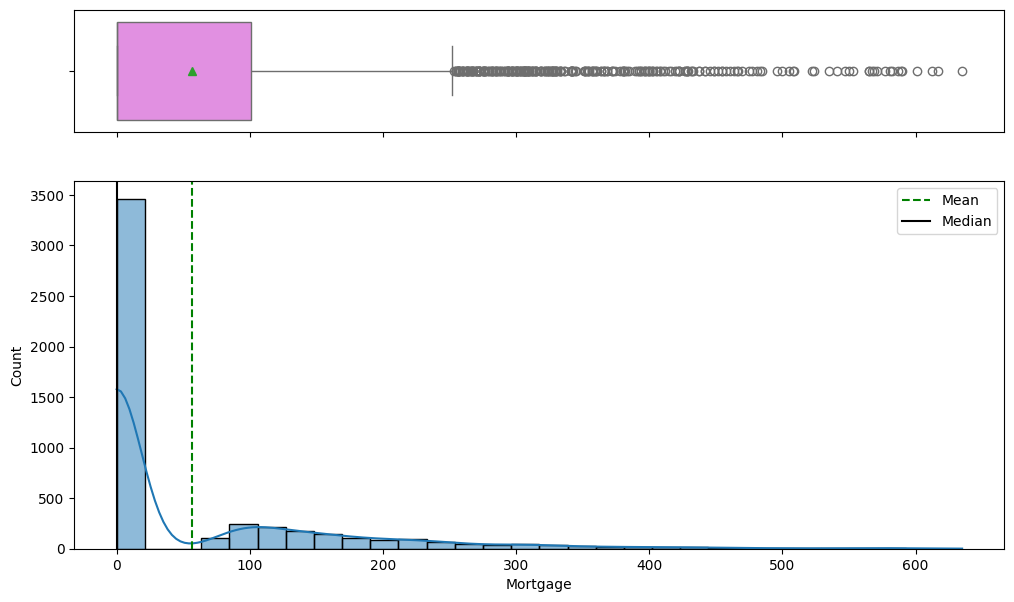

```python
# Plot Histogram + Boxplot (Mortgage)

# Define the histogram + boxplot function
def histogram_boxplot(data, feature, figsize=(12, 7), kde=False, bins=None):
    """
    Boxplot and histogram combined.

    Parameters:
    - data: DataFrame containing the dataset
    - feature: Column name to be visualized
    - figsize: Figure size (default: (12,7))
    - kde: Whether to show the density curve (default: False)
    - bins: Number of bins for histogram (default: None)
    """
    # Create figure with 2 subplots (boxplot + histogram)
    f2, (ax_box2, ax_hist2) = plt.subplots(
        nrows=2,  # Two subplots (boxplot and histogram)
        sharex=True,  # Share x-axis
        gridspec_kw={"height_ratios": (0.25, 0.75)},  # Boxplot takes 25% height, histogram 75%
        figsize=figsize,
    )

    # Create boxplot on the top subplot
    sns.boxplot(
        data=data, x=feature, ax=ax_box2, showmeans=True, color="violet"
    )

    # Create histogram on the bottom subplot
    sns.histplot(
        data=data, x=feature, kde=kde, ax=ax_hist2, bins=bins, palette="winter"
    ) if bins else sns.histplot(
        data=data, x=feature, kde=kde, ax=ax_hist2
    )

    # Add vertical lines for mean and median
    ax_hist2.axvline(
        data[feature].mean(), color="green", linestyle="--", label="Mean"
    )
    ax_hist2.axvline(
        data[feature].median(), color="black", linestyle="-", label="Median"
    )

    # Add legend to histogram
    ax_hist2.legend()

    # Show the plots
    plt.show()

# Generate the histogram + boxplot for the "Mortgage" column
histogram_boxplot(data=df, feature="Mortgage", kde=True, bins=30)
```

- **Observations:**

-- The mortgage data seems to be positive or right skewed due to the mean value being to the right of the median as indicated above in the green and black lines in the histogram chart.

-- A large number of customers do not have a mortgage as indicated by spike at 0 on the barchart above. This indicates a large number of customers might be renters instead of homeowners. I can further analyze age to mortgage to get a better indication of that assumption.

-- The data is right skewed indicating that a large number of customers have lower mortgage values. There are a few outliers with higher mortgages.

```python
# Checking the distribution of Income.
data["Income"].describe()
```

|  | Income |
| --- | --- |
| count | 5000.000000 |
| mean | 73.774200 |
| std | 46.033729 |
| min | 8.000000 |
| 25% | 39.000000 |
| 50% | 64.000000 |
| 75% | 98.000000 |
| max | 224.000000 |

**dtype:** float64

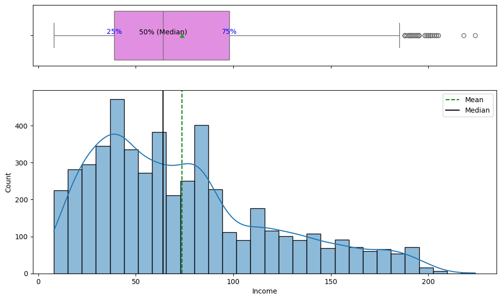

```python
# Plot Histogram + Boxplot (Income)

# Define the histogram + boxplot function
def histogram_boxplot(data, feature, figsize=(12, 7), kde=False, bins=None):
    """
    Boxplot and histogram combined.

    Parameters:
    - data: DataFrame containing the dataset
    - feature: Column name to be visualized
    - figsize: Figure size (default: (12,7))
    - kde: Whether to show the density curve (default: False)
    - bins: Number of bins for histogram (default: None)
    """
    # Create figure with 2 subplots (boxplot + histogram)
    f2, (ax_box2, ax_hist2) = plt.subplots(
        nrows=2,  # Two subplots (boxplot and histogram)
        sharex=True,  # Share x-axis
        gridspec_kw={"height_ratios": (0.25, 0.75)},  # Boxplot takes 25% height, histogram 75%
        figsize=figsize,
    )

    # Calculate percentiles
    q1 = data[feature].quantile(0.25)
    q2 = data[feature].quantile(0.50)  # Median
    q3 = data[feature].quantile(0.75)

    # Create boxplot on the top subplot
    sns.boxplot(
        data=data, x=feature, ax=ax_box2, showmeans=True, color="violet"
    )

    # Label percentiles on the boxplot
    ax_box2.text(q1, 0, "25%", ha="center", va="bottom", fontsize=10, color="blue")
    ax_box2.text(q2, 0, "50% (Median)", ha="center", va="bottom", fontsize=10, color="black")
    ax_box2.text(q3, 0, "75%", ha="center", va="bottom", fontsize=10, color="blue")

    # Create histogram on the bottom subplot
    sns.histplot(
        data=data, x=feature, kde=kde, ax=ax_hist2, bins=bins, palette="winter"
    ) if bins else sns.histplot(
        data=data, x=feature, kde=kde, ax=ax_hist2
    )

    # Add vertical lines for mean and median
    ax_hist2.axvline(
        data[feature].mean(), color="green", linestyle="--", label="Mean"
    )
    ax_hist2.axvline(
        data[feature].median(), color="black", linestyle="-", label="Median"
    )

    # Add legend to histogram
    ax_hist2.legend()

    # Show the plots
    plt.show()

# Generate the histogram + boxplot for the "Mortgage" column
histogram_boxplot(data=df, feature="Income", kde=True, bins=30)
```

- **Observations:**

-- The Income distribution is right skewed because the Mean is larger than the Median as indicated by the dashed green line to the right of the straight black line.

-- The income shows a wide range from 8K to 224K. This is further observed by gthe large standard deviation of 46K.

-- The interquartile range (IQR) is from 39K to 98K, meaning most customers earn within this range.

-- The boxplot shows a large number of outliers above gthe upper whisker.

-- The median income is $64K, meaning half of the customers earn below this value and half the customers earn abovwe this value.

```python
# Checking the distribution of CCAvg.
# Check the distribution of credit card spending
data["CCAvg"].describe()
```

|  | CCAvg |
| --- | --- |
| count | 5000.000000 |
| mean | 1.937938 |
| std | 1.747659 |
| min | 0.000000 |
| 25% | 0.700000 |
| 50% | 1.500000 |
| 75% | 2.500000 |
| max | 10.000000 |

**dtype:** float64

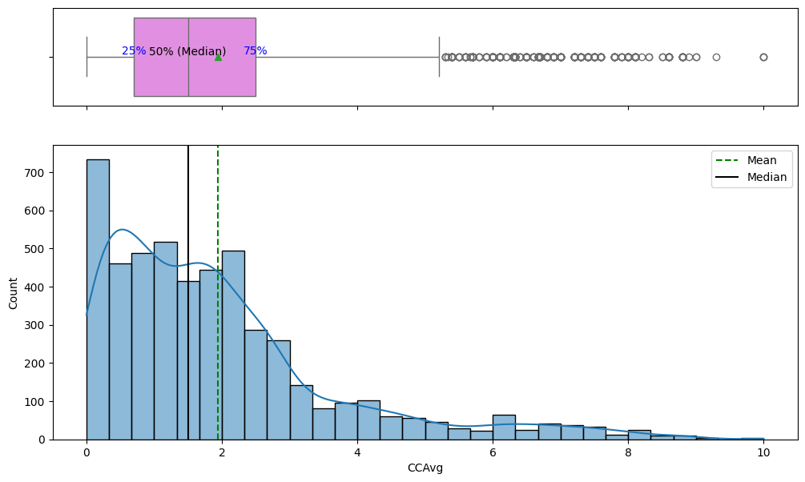

```python
# Plot Histogram + Boxplot (CCAvg)
# Check the distribution of credit card spending

# Define the histogram + boxplot function
def histogram_boxplot(data, feature, figsize=(12, 7), kde=False, bins=None):
    """
    Boxplot and histogram combined.

    Parameters:
    - data: DataFrame containing the dataset
    - feature: Column name to be visualized
    - figsize: Figure size (default: (12,7))
    - kde: Whether to show the density curve (default: False)
    - bins: Number of bins for histogram (default: None)
    """
    # Create figure with 2 subplots (boxplot + histogram)
    f2, (ax_box2, ax_hist2) = plt.subplots(
        nrows=2,  # Two subplots (boxplot and histogram)
        sharex=True,  # Share x-axis
        gridspec_kw={"height_ratios": (0.25, 0.75)},  # Boxplot takes 25% height, histogram 75%
        figsize=figsize,
    )

    # Calculate percentiles
    q1 = data[feature].quantile(0.25)
    q2 = data[feature].quantile(0.50)  # Median
    q3 = data[feature].quantile(0.75)

    # Create boxplot on the top subplot
    sns.boxplot(
        data=data, x=feature, ax=ax_box2, showmeans=True, color="violet"
    )

    # Label percentiles on the boxplot
    ax_box2.text(q1, 0, "25%", ha="center", va="bottom", fontsize=10, color="blue")
    ax_box2.text(q2, 0, "50% (Median)", ha="center", va="bottom", fontsize=10, color="black")
    ax_box2.text(q3, 0, "75%", ha="center", va="bottom", fontsize=10, color="blue")

    # Create histogram on the bottom subplot
    sns.histplot(
        data=data, x=feature, kde=kde, ax=ax_hist2, bins=bins, palette="winter"
    ) if bins else sns.histplot(
        data=data, x=feature, kde=kde, ax=ax_hist2
    )

    # Add vertical lines for mean and median
    ax_hist2.axvline(
        data[feature].mean(), color="green", linestyle="--", label="Mean"
    )
    ax_hist2.axvline(
        data[feature].median(), color="black", linestyle="-", label="Median"
    )

    # Add legend to histogram
    ax_hist2.legend()

    # Show the plots
    plt.show()

# Generate the histogram + boxplot for the "Mortgage" column
histogram_boxplot(data=df, feature="CCAvg", kde=True, bins=30)
```

- **Observations:**

-- Credirt Card balance (spending) for CCAvg is also right skewed as we can see with the Mean value (dashed green line) larger than the Median (vertical black line).

-- 75% of customers spend less than $2.5K, showing that high credit card spending might be uncommon for these customers. Most customers are between 0 and 2.5K.

-- A high number of customers (~730) maintain a 0 balance.

-- I'll be able to gleen more insights when I compare credit card average to income and age.

```python
# Checking the distribution of Experience.
# Years of professional experience
data["Experience"].describe()
```

|  | Experience |
| --- | --- |
| count | 5000.000000 |
| mean | 20.134600 |
| std | 11.415189 |
| min | 0.000000 |
| 25% | 10.000000 |
| 50% | 20.000000 |
| 75% | 30.000000 |
| max | 43.000000 |

**dtype:** float64

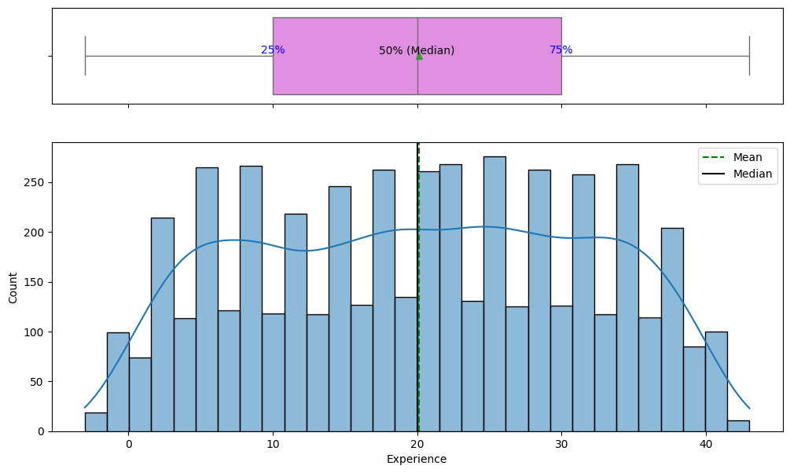

```python
# Plot Histogram + Boxplot (Experience)
# Years of professional experience

# Define the histogram + boxplot function
def histogram_boxplot(data, feature, figsize=(12, 7), kde=False, bins=None):
    """
    Boxplot and histogram combined.

    Parameters:
    - data: DataFrame containing the dataset
    - feature: Column name to be visualized
    - figsize: Figure size (default: (12,7))
    - kde: Whether to show the density curve (default: False)
    - bins: Number of bins for histogram (default: None)
    """
    # Create figure with 2 subplots (boxplot + histogram)
    f2, (ax_box2, ax_hist2) = plt.subplots(
        nrows=2,  # Two subplots (boxplot and histogram)
        sharex=True,  # Share x-axis
        gridspec_kw={"height_ratios": (0.25, 0.75)},  # Boxplot takes 25% height, histogram 75%
        figsize=figsize,
    )

    # Calculate percentiles
    q1 = data[feature].quantile(0.25)
    q2 = data[feature].quantile(0.50)  # Median
    q3 = data[feature].quantile(0.75)

    # Create boxplot on the top subplot
    sns.boxplot(
        data=data, x=feature, ax=ax_box2, showmeans=True, color="violet"
    )

    # Label percentiles on the boxplot
    ax_box2.text(q1, 0, "25%", ha="center", va="bottom", fontsize=10, color="blue")
    ax_box2.text(q2, 0, "50% (Median)", ha="center", va="bottom", fontsize=10, color="black")
    ax_box2.text(q3, 0, "75%", ha="center", va="bottom", fontsize=10, color="blue")

    # Create histogram on the bottom subplot
    sns.histplot(
        data=data, x=feature, kde=kde, ax=ax_hist2, bins=bins, palette="winter"
    ) if bins else sns.histplot(
        data=data, x=feature, kde=kde, ax=ax_hist2
    )

    # Add vertical lines for mean and median
    ax_hist2.axvline(
        data[feature].mean(), color="green", linestyle="--", label="Mean"
    )
    ax_hist2.axvline(
        data[feature].median(), color="black", linestyle="-", label="Median"
    )

    # Add legend to histogram
    ax_hist2.legend()

    # Show the plots
    plt.show()

# Generate the histogram + boxplot for the "Mortgage" column
histogram_boxplot(data=df, feature="Experience", kde=True, bins=30)
```

- **Observations:**

-- Experience data shows a fairly even distribution, which suggests that professional experience is well spread across different customers.

-- The maximum experience is 43 years, meaning the dataset includes individuals with long professional careers.

-- The mean experience is 20.1 years, with a median of 20 years.

-- This suggests that many customers are mid-career professionals.

-- Unlike Income or CCAvg, the Experience histogram is fairly balanced.

```python
# Checking the distribution of Age.
data["Age"].describe()
```

|  | Age |
| --- | --- |
| count | 5000.000000 |
| mean | 45.338400 |
| std | 11.463166 |
| min | 23.000000 |
| 25% | 35.000000 |
| 50% | 45.000000 |
| 75% | 55.000000 |
| max | 67.000000 |

**dtype:** float64

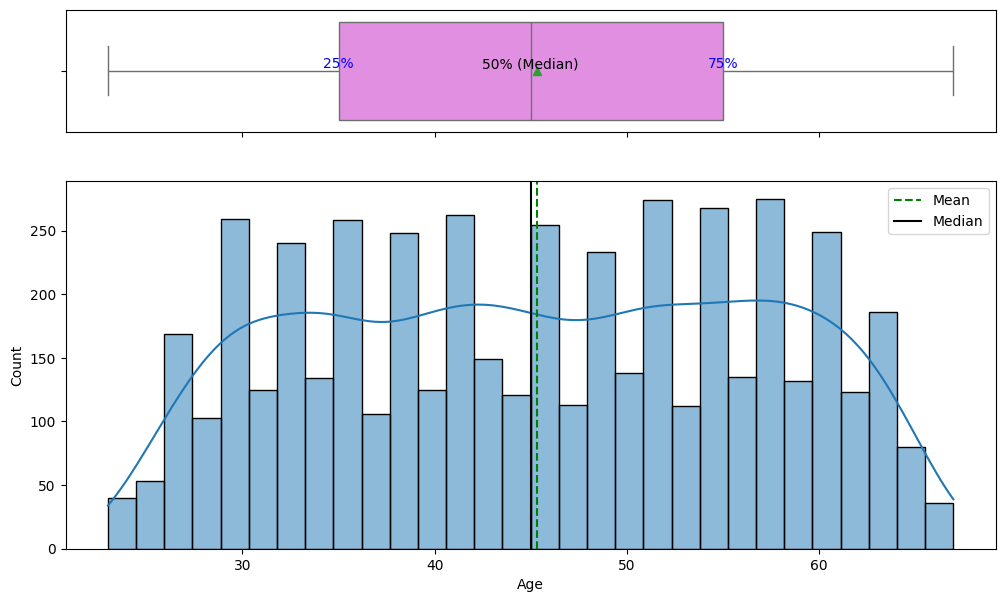

```python
# Plot Histogram + Boxplot (Age)

# Define the histogram + boxplot function
def histogram_boxplot(data, feature, figsize=(12, 7), kde=False, bins=None):
    """
    Boxplot and histogram combined.

    Parameters:
    - data: DataFrame containing the dataset
    - feature: Column name to be visualized
    - figsize: Figure size (default: (12,7))
    - kde: Whether to show the density curve (default: False)
    - bins: Number of bins for histogram (default: None)
    """
    # Create figure with 2 subplots (boxplot + histogram)
    f2, (ax_box2, ax_hist2) = plt.subplots(
        nrows=2,  # Two subplots (boxplot and histogram)
        sharex=True,  # Share x-axis
        gridspec_kw={"height_ratios": (0.25, 0.75)},  # Boxplot takes 25% height, histogram 75%
        figsize=figsize,
    )

    # Calculate percentiles
    q1 = data[feature].quantile(0.25)
    q2 = data[feature].quantile(0.50)  # Median
    q3 = data[feature].quantile(0.75)

    # Create boxplot on the top subplot
    sns.boxplot(
        data=data, x=feature, ax=ax_box2, showmeans=True, color="violet"
    )

    # Label percentiles on the boxplot
    ax_box2.text(q1, 0, "25%", ha="center", va="bottom", fontsize=10, color="blue")
    ax_box2.text(q2, 0, "50% (Median)", ha="center", va="bottom", fontsize=10, color="black")
    ax_box2.text(q3, 0, "75%", ha="center", va="bottom", fontsize=10, color="blue")

    # Create histogram on the bottom subplot
    sns.histplot(
        data=data, x=feature, kde=kde, ax=ax_hist2, bins=bins, palette="winter"
    ) if bins else sns.histplot(
        data=data, x=feature, kde=kde, ax=ax_hist2
    )

    # Add vertical lines for mean and median
    ax_hist2.axvline(
        data[feature].mean(), color="green", linestyle="--", label="Mean"
    )
    ax_hist2.axvline(
        data[feature].median(), color="black", linestyle="-", label="Median"
    )

    # Add legend to histogram
    ax_hist2.legend()

    # Show the plots
    plt.show()

# Generate the histogram + boxplot for the "Mortgage" column
histogram_boxplot(data=df, feature="Age", kde=True, bins=30)
```

- **Observations:**

-- Like Experience, Age data seems to be fairly evenly distributed as well.

-- Age Ranges from 23 to 67 Years.

-- The youngest customer is 23 years old, while the oldest is 67.

-- The mean age is ~45 years, and the median is also 45 years.

-- The interquartile range (IQR) is from 35 to 55 years, meaning most customers fall within this mid-career range.

-- There are no major outliers within Age.

### Univariate Analysis for Categorical Data

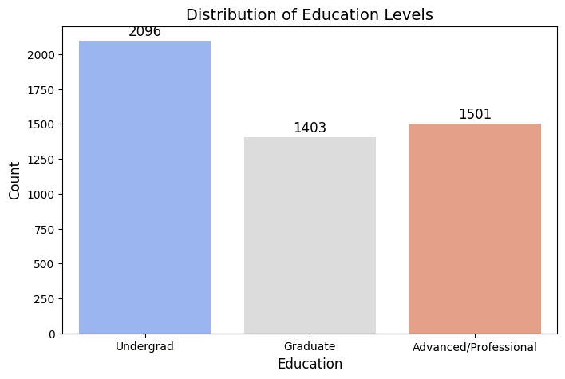

| Education | count |
| --- | --- |
| 2 | 1403 |
| 3 | 1501 |
| 1 | 2096 |

**dtype:** int64

```python
# Univariate Analysis for Categorical data: (Education, Personal_Loan, Securities_Account, CD_Account, Online, CreditCard, and Family)
# Create Barchart for Education

# Define function to create bar charts with custom labels for categorical features
def plot_bar_chart_with_labels(data, feature, title=None, labels=None):
    """
    Function to plot a bar chart for categorical features with custom labels.

    Parameters:
    - data: DataFrame containing the dataset
    - feature: Column name (categorical feature) to visualize
    - title: Custom title for the plot (default: None)
    - labels: Dictionary mapping feature values to custom labels (default: None)
    """
    plt.figure(figsize=(8, 5))

    # Create a bar chart
    ax = sns.countplot(data=data, x=feature, palette="coolwarm")

    # Set title and labels
    plt.title(title if title else f"Distribution of {feature}", fontsize=14)
    plt.xlabel(feature, fontsize=12)
    plt.ylabel("Count", fontsize=12)

    # Set custom labels if provided
    if labels:
        ax.set_xticklabels([labels[val] for val in sorted(data[feature].unique())])

    # Show value counts on bars
    for p in ax.patches:
        ax.annotate(f'{int(p.get_height())}', (p.get_x() + p.get_width() / 2., p.get_height()),
                    ha='center', va='baseline', fontsize=12, color='black', xytext=(0, 5),
                    textcoords='offset points')

    plt.show()

# Define custom labels for Education levels
education_labels = {1: "Undergrad", 2: "Graduate", 3: "Advanced/Professional"}

# Generate bar chart for Education with custom labels
plot_bar_chart_with_labels(data, "Education", "Distribution of Education Levels", labels=education_labels)

# Display value counts in ascending order
data["Education"].value_counts().sort_values(ascending=True)
```

- **Observations:**

-- There are 3 unique education levels.

-- The most common category is "Undergrad".

-- "Graduate" appears 1403 times.

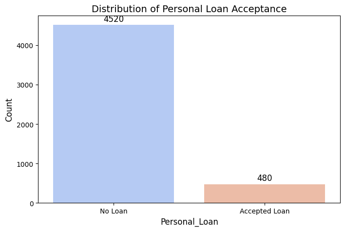

| Personal_Loan | count |
| --- | --- |
| 1 | 480 |
| 0 | 4520 |

**dtype:** int64

```python
# Univariate Analysis for Categorical data: (Education, Personal_Loan, Securities_Account, CD_Account, Online, CreditCard, and Family)
# Create Barchart for Personal_Loan

# Define function to create bar charts for categorical features
def plot_bar_chart(data, feature, title=None, labels=None):
    """
    Function to plot a bar chart for categorical features with optional custom labels.

    Parameters:
    - data: DataFrame containing the dataset
    - feature: Column name (categorical feature) to visualize
    - title: Custom title for the plot (default: None)
    - labels: Dictionary mapping feature values to custom labels (default: None)
    """
    plt.figure(figsize=(8, 5))

    # Create a bar chart
    ax = sns.countplot(data=data, x=feature, palette="coolwarm")

    # Set title and labels
    plt.title(title if title else f"Distribution of {feature}", fontsize=14)
    plt.xlabel(feature, fontsize=12)
    plt.ylabel("Count", fontsize=12)

    # Set custom labels if provided
    if labels:
        ax.set_xticklabels([labels[val] for val in sorted(data[feature].unique())])

    # Show value counts on bars
    for p in ax.patches:
        ax.annotate(f'{int(p.get_height())}', (p.get_x() + p.get_width() / 2., p.get_height()),
                    ha='center', va='baseline', fontsize=12, color='black', xytext=(0, 5),
                    textcoords='offset points')

    plt.show()

# Define custom labels for Personal_Loan (0: No, 1: Yes)
loan_labels = {0: "No Loan", 1: "Accepted Loan"}

# Generate bar chart for Personal_Loan with custom labels
plot_bar_chart(data, "Personal_Loan", "Distribution of Personal Loan Acceptance", labels=loan_labels)

# Display value counts in ascending order
data["Personal_Loan"].value_counts().sort_values(ascending=True)
```

- **Observations:**

-- The majority of customers fall into the "No Loan" category, meaning only a small portion actually took the loan.

-- This creates a large class imbalance which may impact modelling.

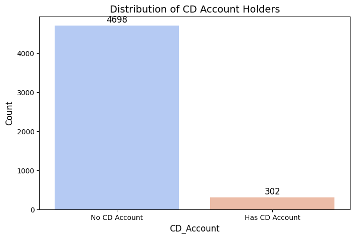

| CD_Account | count |
| --- | --- |
| 1 | 302 |
| 0 | 4698 |

**dtype:** int64

```python
# Univariate Analysis for Categorical data: (Education, Personal_Loan, Securities_Account, CD_Account, Online, CreditCard, and Family)
# Create Barchart for CD_Account

# Define function to create bar charts for categorical features
def plot_bar_chart(data, feature, title=None, labels=None):
    """
    Function to plot a bar chart for categorical features with optional custom labels.

    Parameters:
    - data: DataFrame containing the dataset
    - feature: Column name (categorical feature) to visualize
    - title: Custom title for the plot (default: None)
    - labels: Dictionary mapping feature values to custom labels (default: None)
    """
    plt.figure(figsize=(8, 5))

    # Create a bar chart
    ax = sns.countplot(data=data, x=feature, palette="coolwarm")

    # Set title and labels
    plt.title(title if title else f"Distribution of {feature}", fontsize=14)
    plt.xlabel(feature, fontsize=12)
    plt.ylabel("Count", fontsize=12)

    # Set custom labels if provided
    if labels:
        ax.set_xticklabels([labels[val] for val in sorted(data[feature].unique())])

    # Show value counts on bars
    for p in ax.patches:
        ax.annotate(f'{int(p.get_height())}', (p.get_x() + p.get_width() / 2., p.get_height()),
                    ha='center', va='baseline', fontsize=12, color='black', xytext=(0, 5),
                    textcoords='offset points')

    plt.show()

# Define custom labels for Personal_Loan (0: No, 1: Yes)
CD_Account_labels = {0: "No CD Account", 1: "Has CD Account"}

# Generate bar chart for Personal_Loan with custom labels
plot_bar_chart(data, "CD_Account", "Distribution of CD Account Holders", labels=CD_Account_labels)

# Display value counts in ascending order
data["CD_Account"].value_counts().sort_values(ascending=True)
```

- **Observations:**

-- Similar to Personal Loans, very few customers have CD accounts.

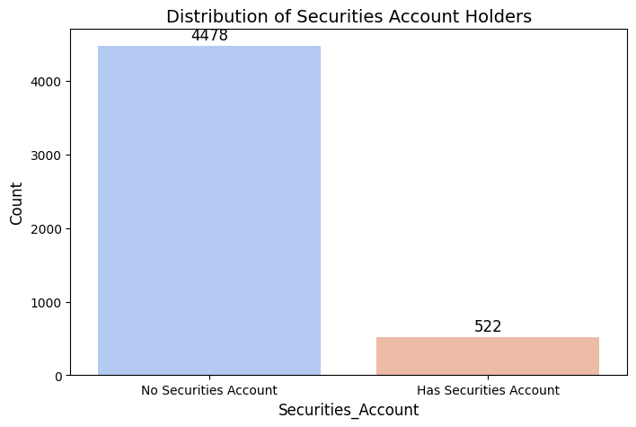

| Securities_Account | count |
| --- | --- |
| 1 | 522 |
| 0 | 4478 |

**dtype:** int64

```python
# Univariate Analysis for Categorical data: (Education, Personal_Loan, Securities_Account, CD_Account, Online, CreditCard, and Family)
# Create Barchart for Securities_Account

# Define function to create bar charts for categorical features
def plot_bar_chart(data, feature, title=None, labels=None):
    """
    Function to plot a bar chart for categorical features with optional custom labels.

    Parameters:
    - data: DataFrame containing the dataset
    - feature: Column name (categorical feature) to visualize
    - title: Custom title for the plot (default: None)
    - labels: Dictionary mapping feature values to custom labels (default: None)
    """
    plt.figure(figsize=(8, 5))

    # Create a bar chart
    ax = sns.countplot(data=data, x=feature, palette="coolwarm")

    # Set title and labels
    plt.title(title if title else f"Distribution of {feature}", fontsize=14)
    plt.xlabel(feature, fontsize=12)
    plt.ylabel("Count", fontsize=12)

    # Set custom labels if provided
    if labels:
        ax.set_xticklabels([labels[val] for val in sorted(data[feature].unique())])

    # Show value counts on bars
    for p in ax.patches:
        ax.annotate(f'{int(p.get_height())}', (p.get_x() + p.get_width() / 2., p.get_height()),
                    ha='center', va='baseline', fontsize=12, color='black', xytext=(0, 5),
                    textcoords='offset points')

    plt.show()

# Define custom labels for Personal_Loan (0: No, 1: Yes)
Security_Account_labels = {0: "No Securities Account", 1: "Has Securities Account"}

# Generate bar chart for Personal_Loan with custom labels
plot_bar_chart(data, "Securities_Account", "Distribution of Securities Account Holders", labels=Security_Account_labels)

# Display value counts in ascending order
data["Securities_Account"].value_counts().sort_values(ascending=True)
```

- **Observations:**

-- The vast majority of customers do not invest in securities through the bank.

-- Similar to CD Accounts, the dataset is imbalanced, with fewer customers owning securities accounts.

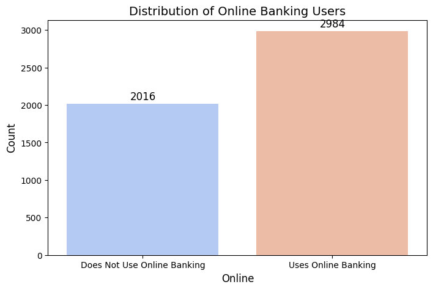

| Online | count |
| --- | --- |
| 0 | 2016 |
| 1 | 2984 |

**dtype:** int64

```python
# Univariate Analysis for Categorical data: (Education, Personal_Loan, Securities_Account, CD_Account, Online, CreditCard, and Family)
# Create Barchart for Online

# Define function to create bar charts for categorical features
def plot_bar_chart(data, feature, title=None, labels=None):
    """
    Function to plot a bar chart for categorical features with optional custom labels.

    Parameters:
    - data: DataFrame containing the dataset
    - feature: Column name (categorical feature) to visualize
    - title: Custom title for the plot (default: None)
    - labels: Dictionary mapping feature values to custom labels (default: None)
    """
    plt.figure(figsize=(8, 5))

    # Create a bar chart
    ax = sns.countplot(data=data, x=feature, palette="coolwarm")

    # Set title and labels
    plt.title(title if title else f"Distribution of {feature}", fontsize=14)
    plt.xlabel(feature, fontsize=12)
    plt.ylabel("Count", fontsize=12)

    # Set custom labels if provided
    if labels:
        ax.set_xticklabels([labels[val] for val in sorted(data[feature].unique())])

    # Show value counts on bars
    for p in ax.patches:
        ax.annotate(f'{int(p.get_height())}', (p.get_x() + p.get_width() / 2., p.get_height()),
                    ha='center', va='baseline', fontsize=12, color='black', xytext=(0, 5),
                    textcoords='offset points')

    plt.show()

# Define custom labels for Personal_Loan (0: No, 1: Yes)
Online_labels = {0: "Does Not Use Online Banking", 1: "Uses Online Banking"}

# Generate bar chart for Personal_Loan with custom labels
plot_bar_chart(data, "Online", "Distribution of Online Banking Users", labels=Online_labels)

# Display value counts in ascending order
data["Online"].value_counts().sort_values(ascending=True)
```

- **Observations:**

-- This data a little more even with about 2/3 or ~60% of the customers using online banking.

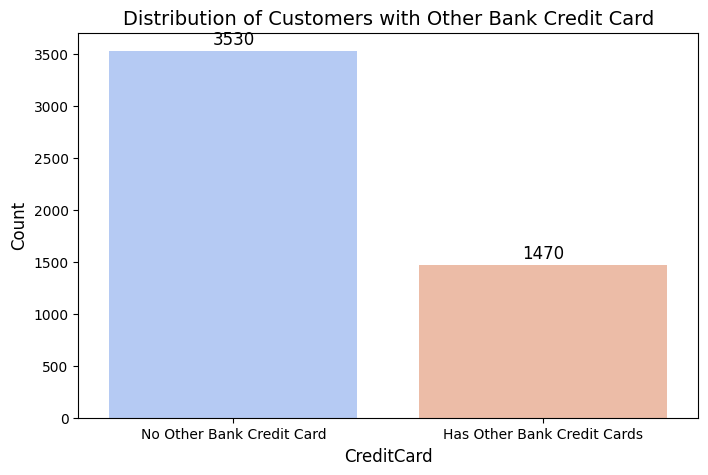

| CreditCard | count |
| --- | --- |
| 1 | 1470 |
| 0 | 3530 |

**dtype:** int64

```python
# Univariate Analysis for Categorical data: (Education, Personal_Loan, Securities_Account, CD_Account, Online, CreditCard, and Family)
# Create Barchart for CreditCard

# Define function to create bar charts for categorical features
def plot_bar_chart(data, feature, title=None, labels=None):
    """
    Function to plot a bar chart for categorical features with optional custom labels.

    Parameters:
    - data: DataFrame containing the dataset
    - feature: Column name (categorical feature) to visualize
    - title: Custom title for the plot (default: None)
    - labels: Dictionary mapping feature values to custom labels (default: None)
    """
    plt.figure(figsize=(8, 5))

    # Create a bar chart
    ax = sns.countplot(data=data, x=feature, palette="coolwarm")

    # Set title and labels
    plt.title(title if title else f"Distribution of {feature}", fontsize=14)
    plt.xlabel(feature, fontsize=12)
    plt.ylabel("Count", fontsize=12)

    # Set custom labels if provided
    if labels:
        ax.set_xticklabels([labels[val] for val in sorted(data[feature].unique())])

    # Show value counts on bars
    for p in ax.patches:
        ax.annotate(f'{int(p.get_height())}', (p.get_x() + p.get_width() / 2., p.get_height()),
                    ha='center', va='baseline', fontsize=12, color='black', xytext=(0, 5),
                    textcoords='offset points')

    plt.show()

# Define custom labels for Personal_Loan (0: No, 1: Yes)
CreditCard_labels = {0: "No Other Bank Credit Card", 1: "Has Other Bank Credit Cards"}

# Generate bar chart for Personal_Loan with custom labels
plot_bar_chart(data, "CreditCard", "Distribution of Customers with Other Bank Credit Card", labels=CreditCard_labels)

# Display value counts in ascending order
data["CreditCard"].value_counts().sort_values(ascending=True)
```

- **Observations:**

-- About 71% of customers do not have any other bank credit cards.

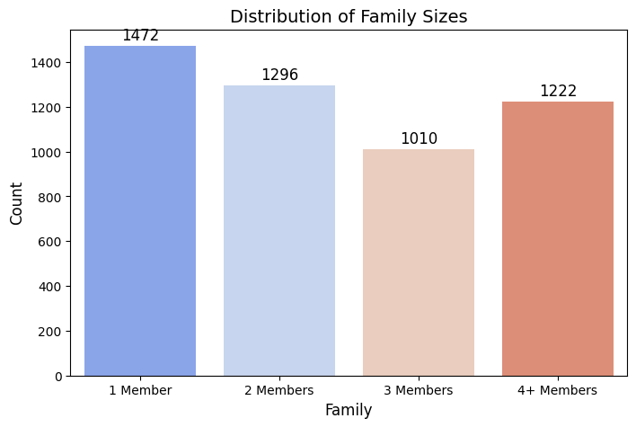

| Family | count |
| --- | --- |
| 3 | 1010 |
| 4 | 1222 |
| 2 | 1296 |
| 1 | 1472 |

**dtype:** int64

```python
# Univariate Analysis for Categorical data: (Education, Personal_Loan, Securities_Account, CD_Account, Online, CreditCard, and Family)
# Create Barchart for Family

# Define function to create bar charts for categorical features
def plot_bar_chart(data, feature, title=None, labels=None):
    """
    Function to plot a bar chart for categorical features with optional custom labels.

    Parameters:
    - data: DataFrame containing the dataset
    - feature: Column name (categorical feature) to visualize
    - title: Custom title for the plot (default: None)
    - labels: Dictionary mapping feature values to custom labels (default: None)
    """
    plt.figure(figsize=(8, 5))

    # Create a bar chart
    ax = sns.countplot(data=data, x=feature, palette="coolwarm")

    # Set title and labels
    plt.title(title if title else f"Distribution of {feature}", fontsize=14)
    plt.xlabel(feature, fontsize=12)
    plt.ylabel("Count", fontsize=12)

    # Set custom labels if provided
    if labels:
        ax.set_xticklabels([labels[val] for val in sorted(data[feature].unique())])

    # Show value counts on bars
    for p in ax.patches:
        ax.annotate(f'{int(p.get_height())}', (p.get_x() + p.get_width() / 2., p.get_height()),
                    ha='center', va='baseline', fontsize=12, color='black', xytext=(0, 5),
                    textcoords='offset points')

    plt.show()

# Define custom labels for Personal_Loan (0: No, 1: Yes)
Family_labels = {1: "1 Member", 2: "2 Members", 3: "3 Members", 4: "4+ Members"}

# Generate bar chart for Personal_Loan with custom labels
plot_bar_chart(data, "Family", "Distribution of Family Sizes", labels=Family_labels)

# Display value counts in ascending order
data["Family"].value_counts().sort_values(ascending=True)
```

- **Observations:**

-- Most customers have 2 to 4+ family members.

#### **Univariate Analysis Summary:**

**Numerical Features (Histograms + Boxplots)**

-- Income → Right-skewed, wide variation, potential outliers.

-- CCAvg (Credit Card Spending) → Right-skewed, few high spenders.

-- Mortgage → Most customers have no mortgage, some outliers.

-- Experience → Fairly even distribution.

-- Age → Evenly distributed, no major outliers.

**Categorical Features (Bar Charts)**

-- Education → Mostly Undergrad & Graduate levels.

-- Personal Loan → Very low acceptance rate, potential class imbalance.

-- CD Account & Securities Account → Low ownership.

-- Online Banking → Majority use online banking.

-- CreditCard (Other Banks) → 71% do not have an external credit card.

-- Family Size → Most customers have 2 to 4+ members.

### Bivariate and Multivariate Analysis

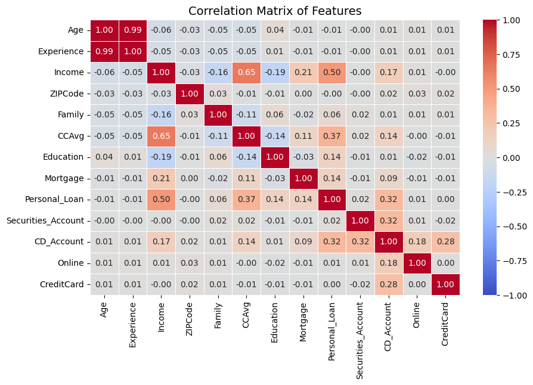

```
Personal_Loan         1.000000
Income                0.502462
CCAvg                 0.366889
CD_Account            0.316355
Mortgage              0.142095
Education             0.136722
Family                0.061367
Securities_Account    0.021954
Online                0.006278
CreditCard            0.002802
ZIPCode              -0.000607
Age                  -0.007726
Experience           -0.008304
Name: Personal_Loan, dtype: float64
```

```python
# Bivariate and Multivariate Analysis
# Print Correlation Matrix

# Compute the correlation matrix
correlation_matrix = data.corr()

# Set up the matplotlib figure
plt.figure(figsize=(10, 6))

# Generate a heatmap for correlations
sns.heatmap(correlation_matrix, annot=True, fmt=".2f", cmap="coolwarm", linewidths=0.5, vmin=-1, vmax=1)

# Set title
plt.title("Correlation Matrix of Features", fontsize=14)

# Show the plot
plt.show()

# Identify the top correlations with the target variable (Personal_Loan)
correlation_with_target = correlation_matrix["Personal_Loan"].sort_values(ascending=False)

# Display sorted correlation values
print(correlation_with_target)
```

- **Observations:**

-- There is a very strong correlation between age and experience which is to be expected but is probably not relevant to our target of Personal Loan.

-- The highest correlation to our target is Income which is .5, which also makes sense. A close contender is CCAvg which has a .37 correlation.

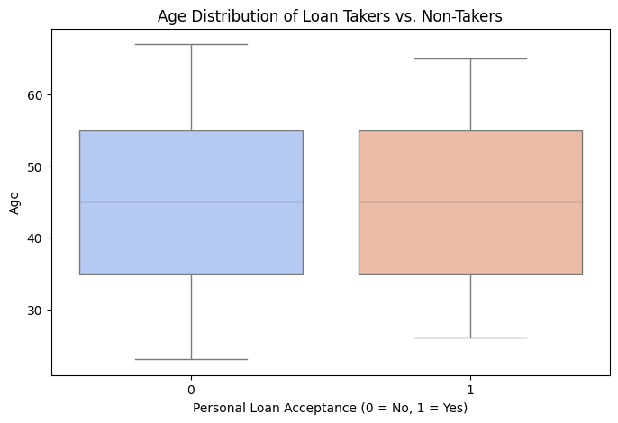

| Personal_Loan | count | mean | std | min | 25% | 50% | 75% | max |
| --- | --- | --- | --- | --- | --- | --- | --- | --- |
| 0 | 4520.0 | 45.367257 | 11.450427 | 23.0 | 35.0 | 45.0 | 55.0 | 67.0 |
| 1 | 480.0 | 45.066667 | 11.590964 | 26.0 | 35.0 | 45.0 | 55.0 | 65.0 |

```python
# Compare Average Age of Loan Takers vs. Non-Takers

plt.figure(figsize=(8, 5))
sns.boxplot(data=data, x="Personal_Loan", y="Age", palette="coolwarm")
plt.title("Age Distribution of Loan Takers vs. Non-Takers")
plt.xlabel("Personal Loan Acceptance (0 = No, 1 = Yes)")
plt.ylabel("Age")
plt.show()

data.groupby("Personal_Loan")["Age"].describe()
```

- **Observations:**

-- Since both (Descriptive Statistics) and (Boxplot Analysis) show that Age is evenly distributed among loan takers and non-takers, this suggests that Age does not strongly influence loan decisions.

-- Since the median and overall distribution of Age are similar for both groups, it means that customers of all ages are equally likely (or unlikely) to take a loan.

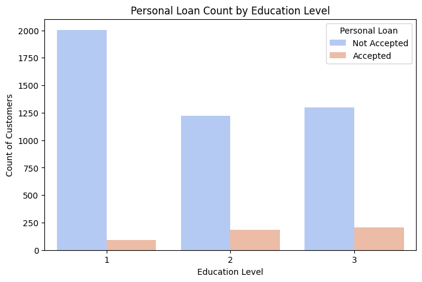

```python
# Generate a bar chart to compare loan acceptance across education levels

# Generate a bar chart to show the count of loan acceptance per education level
plt.figure(figsize=(8, 5))
sns.countplot(x="Education", hue="Personal_Loan", data=data, palette="coolwarm")

# Set labels and title
plt.xlabel("Education Level")
plt.ylabel("Count of Customers")
plt.title("Personal Loan Count by Education Level")
plt.legend(title="Personal Loan", labels=["Not Accepted", "Accepted"])

# Show the plot
plt.show()
```

- **Observations:**

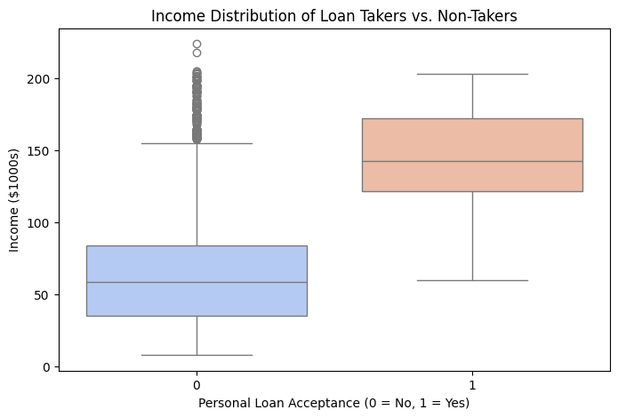

```python
# Create a boxplot of Income vs. Loan Acceptance
plt.figure(figsize=(8, 5))
sns.boxplot(x="Personal_Loan", y="Income", data=data, palette="coolwarm")

# Set labels and title
plt.xlabel("Personal Loan Acceptance (0 = No, 1 = Yes)")
plt.ylabel("Income ($1000s)")
plt.title("Income Distribution of Loan Takers vs. Non-Takers")

# Show the plot
plt.show()
```

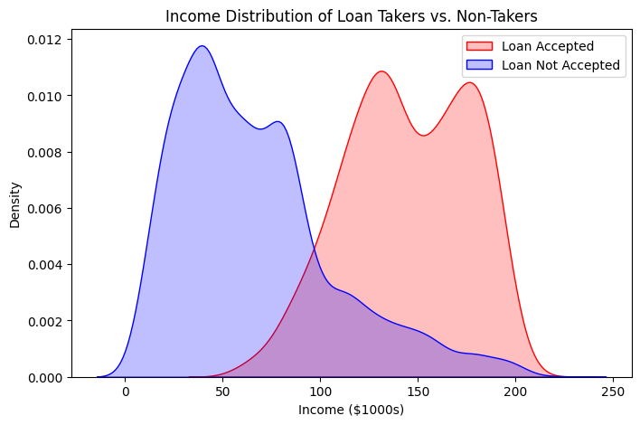

```python
# Create a KDE Plot of Income vs. Loan Acceptance
plt.figure(figsize=(8, 5))
sns.kdeplot(data[data["Personal_Loan"] == 1]["Income"], label="Loan Accepted", shade=True, color="red")
sns.kdeplot(data[data["Personal_Loan"] == 0]["Income"], label="Loan Not Accepted", shade=True, color="blue")

# Set labels and title
plt.xlabel("Income ($1000s)")
plt.ylabel("Density")
plt.title("Income Distribution of Loan Takers vs. Non-Takers")
plt.legend()
plt.show()
```

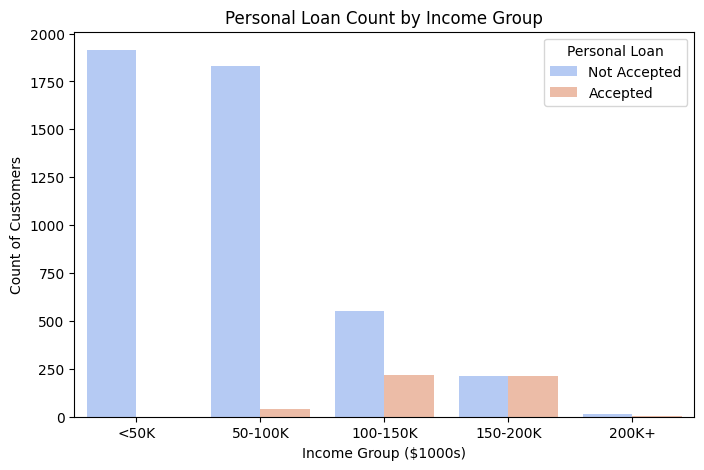

```python
# Create Income Bins
bins = [0, 50, 100, 150, 200, 250]
labels = ["<50K", "50-100K", "100-150K", "150-200K", "200K+"]
data["Income_Group"] = pd.cut(data["Income"], bins=bins, labels=labels)

# Plot Loan Acceptance by Income Group
plt.figure(figsize=(8, 5))
sns.countplot(x="Income_Group", hue="Personal_Loan", data=data, palette="coolwarm")

# Set labels and title
plt.xlabel("Income Group ($1000s)")
plt.ylabel("Count of Customers")
plt.title("Personal Loan Count by Income Group")
plt.legend(title="Personal Loan", labels=["Not Accepted", "Accepted"])

# Show the plot
plt.show()
```

- **Observations:**

-- The median income for loan takers (1) is noticeably higher than for non-takers (0) and there apears to be two groups of income levels that have taken loans. 100K-150K and 150K -200K. You can also see this in the KDE Plot above - suggesting that loan acceptance might be concentrated at two different income levels at middle-income and high-income customers.

-- This suggests that higher-income individuals are more likely to take loans.

-- There are some high-income outliers among non-loan takers beyond 200K. This suggests that some wealthy individuals may not need loans, despite being eligible.

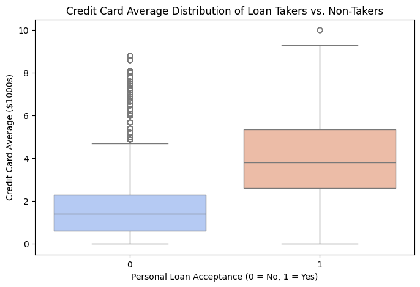

```python
# Create a boxplot of CCAvge "credit card spending" vs. Loan Acceptance
plt.figure(figsize=(8, 5))
sns.boxplot(x="Personal_Loan", y="CCAvg", data=data, palette="coolwarm")

# Set labels and title
plt.xlabel("Personal Loan Acceptance (0 = No, 1 = Yes)")
plt.ylabel("Credit Card Average ($1000s)")
plt.title("Credit Card Average Distribution of Loan Takers vs. Non-Takers")

# Show the plot
plt.show()
```

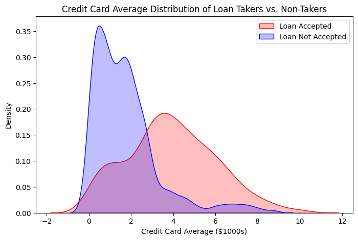

```python
# Create a KDE Plot of Income vs. Loan Acceptance
plt.figure(figsize=(8, 5))
sns.kdeplot(data[data["Personal_Loan"] == 1]["CCAvg"], label="Loan Accepted", shade=True, color="red")
sns.kdeplot(data[data["Personal_Loan"] == 0]["CCAvg"], label="Loan Not Accepted", shade=True, color="blue")

# Set labels and title
plt.xlabel("Credit Card Average ($1000s)")
plt.ylabel("Density")
plt.title("Credit Card Average Distribution of Loan Takers vs. Non-Takers")
plt.legend()
plt.show()
```

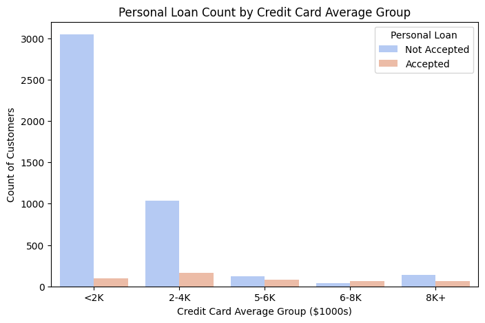

```python
# Ensure "CCAvg" is numeric before binning - this is just good practice but I already know CCAvg is a numeric datatype.
data["CCAvg"] = pd.to_numeric(data["CCAvg"], errors="coerce")

# Drop any NaN values in "CCAvg" before binning - this is just good practice but I already know there are non null values in the dataset.
data = data.dropna(subset=["CCAvg"])

# Create Credit Card Balance Bins
bins = [0, 2, 4, 5, 6, 8]
labels = ["<2K", "2-4K", "5-6K", "6-8K", "8K+"]
data["CCavg_Group"] = pd.cut(data["CCAvg"], bins=bins, labels=labels)

# Plot Loan Acceptance by Credit Card Average Group
plt.figure(figsize=(8, 5))
sns.countplot(x="CCavg_Group", hue="Personal_Loan", data=data, palette="coolwarm")

# Set labels and title
plt.xlabel("Credit Card Average Group ($1000s)")
plt.ylabel("Count of Customers")
plt.title("Personal Loan Count by Credit Card Average Group")
plt.legend(title="Personal Loan", labels=["Not Accepted", "Accepted"])

# Show the plot
plt.show()
```

- **Observations:**

-- Similar to income level, there seems to be a correlation with loan takers and customers with credit card balances around 2K and above, peaking around 4K. Higher Credit Card Spending Correlates with Higher Loan Acceptance

-- Low-Spending Customers Rarely Take Loans according to our data.

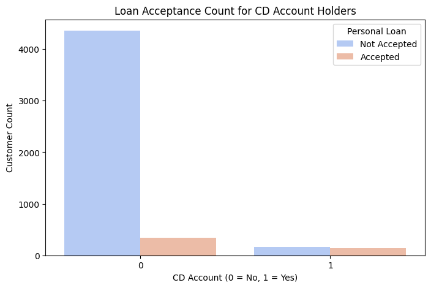

```python
# Generate a bar chart to compare CD Account holders vs. Loan Acceptance
plt.figure(figsize=(8, 5))
sns.countplot(x="CD_Account", hue="Personal_Loan", data=data, palette="coolwarm")

# Set labels and title
plt.xlabel("CD Account (0 = No, 1 = Yes)")
plt.ylabel("Customer Count")
plt.title("Loan Acceptance Count for CD Account Holders")
plt.legend(title="Personal Loan", labels=["Not Accepted", "Accepted"])

# Show the plot
plt.show()
```

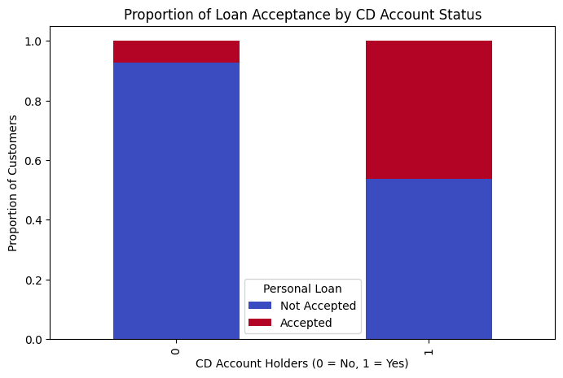

```python
# Create a normalized cross-tabulation (percentage within each CD Account category)
cd_loan_counts = pd.crosstab(data["CD_Account"], data["Personal_Loan"], normalize="index")

# Plot stacked bar chart
cd_loan_counts.plot(kind="bar", stacked=True, colormap="coolwarm", figsize=(8,5))

# Set labels and title
plt.xlabel("CD Account Holders (0 = No, 1 = Yes)")
plt.ylabel("Proportion of Customers")
plt.title("Proportion of Loan Acceptance by CD Account Status")
plt.legend(title="Personal Loan", labels=["Not Accepted", "Accepted"])

# Show the plot
plt.show()
```

- **Observations:**

-- This barchart shows CD Account Holders are more likely to accept a loan offer.

-- Non-CD Holders rarely accept loans and the vast majority of the bank's customers do not have a CD Account.

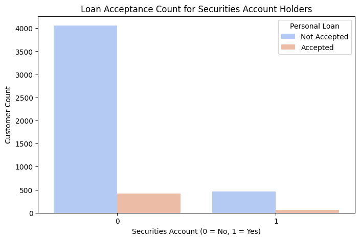

```python
# Generate a bar chart to compare Securities Account holders vs. Loan Acceptance
plt.figure(figsize=(8, 5))
sns.countplot(x="Securities_Account", hue="Personal_Loan", data=data, palette="coolwarm")

# Set labels and title
plt.xlabel("Securities Account (0 = No, 1 = Yes)")
plt.ylabel("Customer Count")
plt.title("Loan Acceptance Count for Securities Account Holders")
plt.legend(title="Personal Loan", labels=["Not Accepted", "Accepted"])

# Show the plot
plt.show()
```

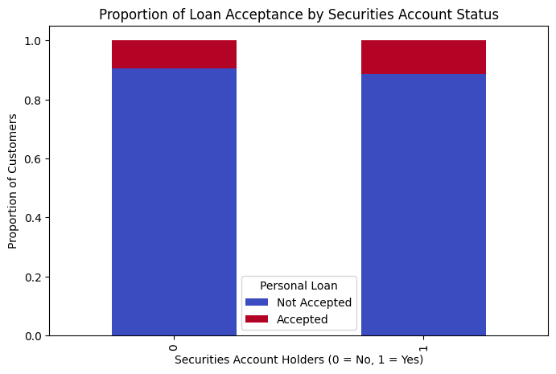

```python
# Create a normalized cross-tabulation (percentage within each Securities Account category)
securities_loan_counts = pd.crosstab(data["Securities_Account"], data["Personal_Loan"], normalize="index")

# Plot stacked bar chart
securities_loan_counts.plot(kind="bar", stacked=True, colormap="coolwarm", figsize=(8,5))

# Set labels and title
plt.xlabel("Securities Account Holders (0 = No, 1 = Yes)")
plt.ylabel("Proportion of Customers")
plt.title("Proportion of Loan Acceptance by Securities Account Status")
plt.legend(title="Personal Loan", labels=["Not Accepted", "Accepted"])

# Show the plot
plt.show()
```

- **Observations:**

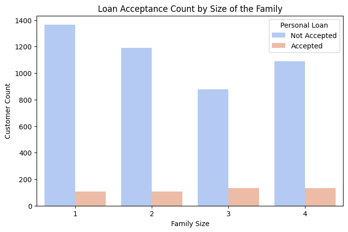

```python
# Generate a bar chart to compare Family Size vs. Loan Acceptance
plt.figure(figsize=(8, 5))
sns.countplot(x="Family", hue="Personal_Loan", data=data, palette="coolwarm")

# Set labels and title
plt.xlabel("Family Size")
plt.ylabel("Customer Count")
plt.title("Loan Acceptance Count by Size of the Family")
plt.legend(title="Personal Loan", labels=["Not Accepted", "Accepted"])

# Show the plot
plt.show()
```

```python
# Create a normalized cross-tabulation (percentage within each Family Size category)
family_loan_counts = pd.crosstab(data["Family"], data["Personal_Loan"], normalize="index")

# Rename columns for clarity
family_loan_counts.columns = ["% Not Accepted (0)", "% Accepted (1)"]

# Display the percentage distribution
family_loan_counts * 100  # Convert proportions to percentages
```

| Family | % Not Accepted (0) | % Accepted (1) |
| --- | --- | --- |
| 1 | 92.730978 | 7.269022 |
| 2 | 91.820988 | 8.179012 |
| 3 | 86.831683 | 13.168317 |
| 4 | 89.034370 | 10.965630 |

- **Observations:**

-- Loan acceptance increases slightly for families with 3-4 family members.

-- Families with 3 members have the highest loan acceptance rate (13.2%). This suggests that middle-sized families might be more financially stable or comfortable taking loans.

-- Single-member families (7.3%) and two-member families (8.2%) are least likely to take loans.

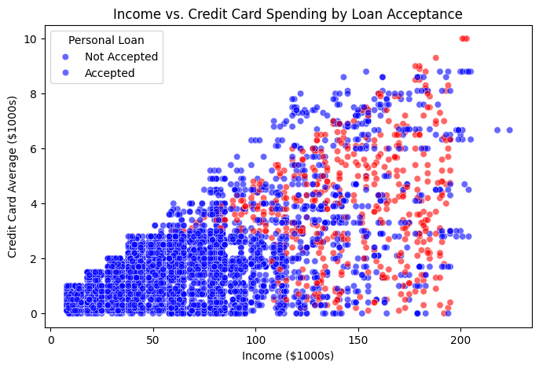

```python
# Generate a scatter plot to analyze the relationship between Income, CCAvg, and Loan Acceptance since these had good correlation
plt.figure(figsize=(8, 5))
sns.scatterplot(data=data, x="Income", y="CCAvg", hue="Personal_Loan", palette=["blue", "red"], alpha=0.6)

# Set labels and title
plt.xlabel("Income ($1000s)")
plt.ylabel("Credit Card Average ($1000s)")
plt.title("Income vs. Credit Card Spending by Loan Acceptance")
plt.legend(title="Personal Loan", labels=["Not Accepted", "Accepted"])

# Show the plot
plt.show()
```

- **Observations:**

-- Loan Takers (Red Dots) tend to have higher incomes and higher credit card balances based on the scatterplot above.

-- Most of the loan acceptances (red) are concentrated in the right to upper-right region of the plot. This suggests that higher-income individuals who spend more on credit cards are more likely to take a loan.

-- There are many blue dots (not accepted) at lower income and lower CCAvg levels. However, even some high-income individuals do not accept loans, indicating that income alone is not a deciding factor.

## Data Preprocessing Cont.

### Outlier Detection

- Block 1: Compute IQR and Outlier Bounds:

```python
# Step 1: Compute Q1 (25th percentile) and Q3 (75th percentile)
Q1 = data.select_dtypes(include=["float64", "int64"]).quantile(0.25)
Q3 = data.select_dtypes(include=["float64", "int64"]).quantile(0.75)

# Step 2: Compute Interquartile Range (IQR)
IQR = Q3 - Q1  # Measures the spread of the middle 50% of the data

# Step 3: Compute Lower and Upper Bound for Outliers
lower = Q1 - 1.5 * IQR  # Lower bound for outliers
upper = Q3 + 1.5 * IQR  # Upper bound for outliers
```

- Block 2: Compute the Percentage of Outliers

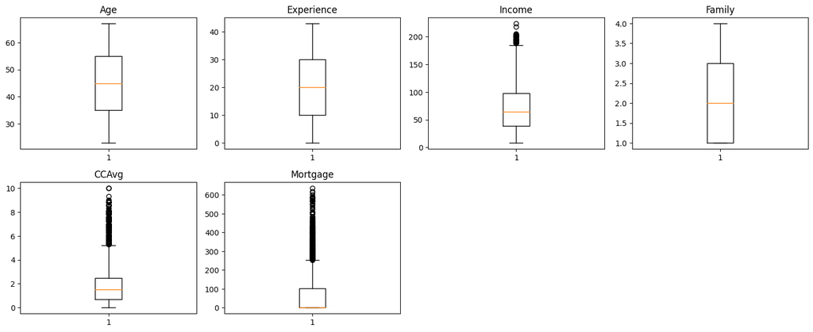

```python
# outlier detection using boxplot
numeric_columns = data.select_dtypes(include=np.number).columns.tolist()

plt.figure(figsize=(15, 12))

for i, variable in enumerate(numeric_columns):
    plt.subplot(4, 4, i + 1)
    plt.boxplot(data[variable], whis=1.5)
    plt.tight_layout()
    plt.title(variable)

plt.show()
```

```python
(
    (data.select_dtypes(include=["float64", "int64"]) < lower)
    | (data.select_dtypes(include=["float64", "int64"]) > upper)
).sum() / len(data) * 100
```

|  | 0 |
| --- | --- |
| Age | 0.00 |
| Experience | 0.00 |
| Income | 1.92 |
| Family | 0.00 |
| CCAvg | 6.48 |
| Mortgage | 5.82 |

**dtype:** float64

- **Observations:**

-- This shows there are no outliers in Age, Experience, or Family

-- There are some outliers in **Income** (1.92%), **CCAvg** (6.48%), and **Mortgage** (5.82%)

### Data Preparation for Modeling

```python
# Check correlation between Age and Experience
correlation = data["Age"].corr(data["Experience"])
print(f"Correlation between Age and Experience: {correlation:.4f}")
```

```
Correlation between Age and Experience: 0.9940
```

- **Observations:**

-- The Pearson correlation between Age and Experience to confirm correlation:

-- with a correlation of >.95 (**.9940**), "Experience" and "Age" appear to be highly redundant so I will drop "Experience" before modeling.

- I will also drop my categorical bin groups (**Income_Group, CCavg_Group**)

```python
# Drop Experience (highly correlated with Age) and categorical bin groups (Income_Group, CCavg_Group)
X = data.drop(["Personal_Loan", "Experience", "Income_Group", "CCavg_Group"], axis=1)

# Convert categorical variables to numerical using one-hot encoding
X = pd.get_dummies(X, columns=["ZIPCode", "Education", "Securities_Account",
                               "CD_Account", "Online", "CreditCard"], drop_first=True)

# Convert everything to float
X = X.astype(float)

# Define target variable
Y = data["Personal_Loan"].astype(int)  # Ensure it's numeric for modeling

# Split data into training (70%) and testing (30%) sets. Stratify on Y to ensure similar equal distribution
X_train, X_test, y_train, y_test = train_test_split(X, Y, test_size=0.30, stratify=Y, random_state=1)

# Verify the new dataset structure
print("Training Set Shape:", X_train.shape)
print("Testing Set Shape:", X_test.shape)
```

```
Training Set Shape: (3500, 17)
Testing Set Shape: (1500, 17)
```

```python
print("Shape of Training set : ", X_train.shape)
print("Shape of test set : ", X_test.shape)
print("Percentage of classes in training set:")
print(y_train.value_counts(normalize=True))
print("Percentage of classes in test set:")
print(y_test.value_counts(normalize=True))
```

```
Shape of Training set :  (3500, 17)
Shape of test set :  (1500, 17)
Percentage of classes in training set:
Personal_Loan
0    0.904
1    0.096
Name: proportion, dtype: float64
Percentage of classes in test set:
Personal_Loan
0    0.904
1    0.096
Name: proportion, dtype: float64
```

- **Observations:**

-- **Stratify on Y** above to ensure similar distribution between the classes in train and test. After Stratify the distributions are exactly the same.

```python
X.info()
```

```
<class 'pandas.core.frame.DataFrame'>
RangeIndex: 5000 entries, 0 to 4999
Data columns (total 17 columns):
 #   Column                Non-Null Count  Dtype
---  ------                --------------  -----
 0   Age                   5000 non-null   float64
 1   Income                5000 non-null   float64
 2   Family                5000 non-null   float64
 3   CCAvg                 5000 non-null   float64
 4   Mortgage              5000 non-null   float64
 5   ZIPCode_91            5000 non-null   float64
 6   ZIPCode_92            5000 non-null   float64
 7   ZIPCode_93            5000 non-null   float64
 8   ZIPCode_94            5000 non-null   float64
 9   ZIPCode_95            5000 non-null   float64
 10  ZIPCode_96            5000 non-null   float64
 11  Education_2           5000 non-null   float64
 12  Education_3           5000 non-null   float64
 13  Securities_Account_1  5000 non-null   float64
 14  CD_Account_1          5000 non-null   float64
 15  Online_1              5000 non-null   float64
 16  CreditCard_1          5000 non-null   float64
dtypes: float64(17)
memory usage: 664.2 KB
```

- **Observations:**

-- This now shows my new data set features for modeling:

-- I have 17 features (columns) in my dataset.

-- My dataset is correctly split (70% train, 30% test).

## Model Building and Performance Improvement

### Model Evaluation Criterion

- For this business case objective of trying to expand the bank's loan business and market to those individuals it feels would likely accept a loan offer, I'm going to move forward with reducing false negatives and use **Recall** as my **model evaluation criteria**.
- This:

-- **Minimizes False Negatives (FN)** → Ensures that qualified potential loan customers aren’t mistakenly rejected.

-- **Maximizes Customer Reach** → Helps identify as many loan-eligible customers as possible.

-- **Supports Business Growth** → Focuses on capturing more customers rather than just avoiding bad approvals as would potentially be the case if I used Precision as my model evaulation criteria.

-- I considered using F1 to strike a balance between Recall and Precision, however I am going to use Recall as my final model evaluation criteria.

-- The company would want the recall to be maximized, the greater the recall score is, the higher are the chances of minimizing the False Negatives.

First, let's create functions to calculate different metrics and confusion matrix so that we don't have to use the same code repeatedly for each model.

-- The **model_performance_classification_sklearn** function will be used to check the model performance of models.

-- The **confusion_matrix_sklearn function** will be used to plot confusion matrix.

```python
# defining a function to compute different metrics to check performance of a classification model built using sklearn
def model_performance_classification_sklearn(model, predictors, target):
    """
    Function to compute different metrics to check classification model performance

    model: classifier
    predictors: independent variables
    target: dependent variable
    """

    # predicting using the independent variables
    pred = model.predict(predictors)

    acc = accuracy_score(target, pred)  # to compute Accuracy
    recall = recall_score(target, pred)  # to compute Recall
    precision = precision_score(target, pred)  # to compute Precision
    f1 = f1_score(target, pred)  # to compute F1-score

    # creating a dataframe of metrics
    df_perf = pd.DataFrame(
        {"Accuracy": acc, "Recall": recall, "Precision": precision, "F1": f1,},
        index=[0],
    )

    return df_perf
```

```python
def confusion_matrix_sklearn(model, predictors, target):
    """
    To plot the confusion_matrix with percentages

    model: classifier
    predictors: independent variables
    target: dependent variable
    """
    y_pred = model.predict(predictors)
    cm = confusion_matrix(target, y_pred)
    labels = np.asarray(
        [
            ["{0:0.0f}".format(item) + "\n{0:.2%}".format(item / cm.flatten().sum())]
            for item in cm.flatten()
        ]
    ).reshape(2, 2)

    plt.figure(figsize=(6, 4))
    sns.heatmap(cm, annot=labels, fmt="")
    plt.ylabel("True label")
    plt.xlabel("Predicted label")
```

### Decision Tree (default)

```python
model0 = DecisionTreeClassifier(random_state=1)
model0.fit(X_train, y_train)
```

```
DecisionTreeClassifier(random_state=1)
```

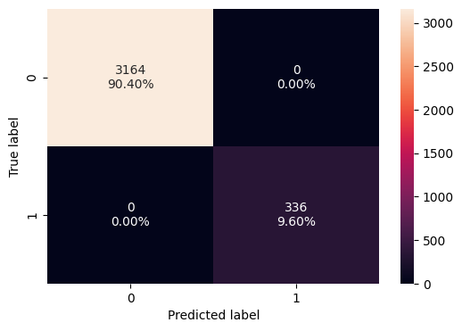

```python
confusion_matrix_sklearn(model0, X_train, y_train)
```

```python
decision_tree_default_perf_train = model_performance_classification_sklearn(
    model0, X_train, y_train
)
decision_tree_default_perf_train
```

|  | Accuracy | Recall | Precision | F1 |
| --- | --- | --- | --- | --- |
| 0 | 1.0 | 1.0 | 1.0 | 1.0 |

- **Observations:**

-- My default model is overfitting on the training data.

-- This can be seen with zero errors in false positives and zero errors in false negatives and the perfect scores in Accuracy, Recall, Precision, and F1.

-- This means the model has memorized the training data instead of generalizing to unseen data.

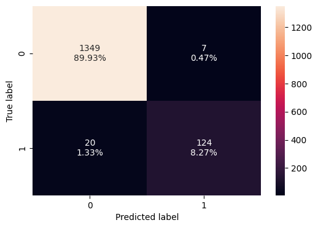

```python
confusion_matrix_sklearn(model0, X_test, y_test)
```

```python
decision_tree_default_perf_test = model_performance_classification_sklearn(
    model0, X_test, y_test
)
decision_tree_default_perf_test
```

|  | Accuracy | Recall | Precision | F1 |
| --- | --- | --- | --- | --- |
| 0 | 0.982 | 0.861111 | 0.946565 | 0.901818 |

- **Observations:**

-- You can see for the default model, all criteria values have slightly decreased for the **Test dataset**, which is to be expected.

### Decision Tree (With Class Weights)

Since my dataset has an imbalanced distribution where the "**No Loan**" class dominates the "**Loan Accepted**" class, my Decision Tree may be biased towards predicting "No Loan" more frequently.

**Setting class_weight="balanced"** helps the model handle class imbalance by giving more importance to the minority class (Loan Accepted), ensuring the tree does not ignore it.

```python
model1 = DecisionTreeClassifier(random_state=1, class_weight="balanced")
model1.fit(X_train, y_train)
```

```
DecisionTreeClassifier(class_weight='balanced', random_state=1)
```

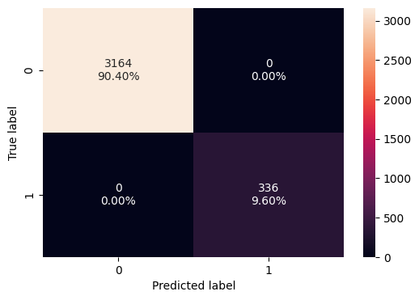

```python
confusion_matrix_sklearn(model1, X_train, y_train)
```

```python
decision_tree_perf_train = model_performance_classification_sklearn(
    model1, X_train, y_train
)
decision_tree_perf_train
```

|  | Accuracy | Recall | Precision | F1 |
| --- | --- | --- | --- | --- |
| 0 | 1.0 | 1.0 | 1.0 | 1.0 |

- **Observations:**
- Here again with this model you can see the model is overfitting to the **Training dataset**.

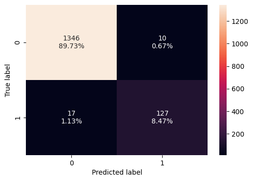

```python
confusion_matrix_sklearn(model1, X_test, y_test)
```

```python
decision_tree_perf_test = model_performance_classification_sklearn(
    model1, X_test, y_test
)
decision_tree_perf_test
```

|  | Accuracy | Recall | Precision | F1 |
| --- | --- | --- | --- | --- |
| 0 | 0.982 | 0.881944 | 0.927007 | 0.903915 |

- **Observations:**

-- There is a disparity in performance of model on training set and test set, which suggests that the model is overfiiting.

**Implementing pruning techniques to try and reduce overfitting.**